# Mapping Migration: Insights Through Data

Data Analytics and Visualization, Fall 2024

Author

Affiliation

Mehak Garg & Shivani Manivasagan

Harvey Mudd College

Published

December 9, 2024

# Introduction and Motivation

The topic we have chosen is historical global asylum data. The dataset offers information on asylum seekers and refugees worldwide giving us context on global refugee patterns, their origins, and their final destinations. This dataset falls at the intersection of human rights, international relations, and global socioeconomic dynamics. Our analysis could potentially explain some of the global displacement patterns researchers have noticed over the past few decades.

In more formal settings, researchers, policymakers, and humanitarian organizations can look at this data to understand patterns of forced migration, identify crisis hotspots, and assess the effectiveness of asylum policies in different countries. It can reveal trends in global conflicts, environmental disasters, and political instability that drive people to seek refuge. This data can then be used as a baseline for evaluating resource allocation and refugee assistance programs.

While we probably will not be able to completely answer these questions, we can take a granular look at how refugee trends have shifted over the last twenty years, which countries are experiencing higher levels of emigration versus immigration, and how approval and denial rates have fluctuated.

# Data at a Glance:

## Visualization 1:

This dynamic animated map visually captures the global patterns of asylum applications from 2000 to 2020. Each country is represented by a unique color gradient, where darker shades signify higher numbers of asylum seekers in a given year. The animation provides interactivity: users can pause it at any point and hover over a country to view precise applicant counts for that year, offering a clear and detailed exploration of the data.

The map highlights striking trends, such as persistently high numbers of asylum seekers in regions like the Middle East and Central Africa. This pattern aligns with broader understandings of these areas as hotspots of political instability, armed conflict, and displacement crises. For instance, countries like Syria and South Sudan consistently display darker shades, reflecting the turmoil and forced migration triggered by prolonged conflict and humanitarian emergencies.

```python
import plotly.express as px
import pandas as pd

applications_df = pd.read_csv('./asylum-applications.csv')
decisions_df = pd.read_csv('./asylum-decisions.csv')
applications_df.loc[applications_df["Country of origin"] == "Unknown "]
applications_clean_df = applications_df[applications_df["Country of origin"] != "Unknown "]
apps_by_country = applications_clean_df.groupby(["Country of origin", "Year", "Country of origin (ISO)"])["applied"].sum().reset_index()
apps_by_country = apps_by_country.sort_values(by="applied", ascending=False)
quantile_bins = pd.qcut(apps_by_country['applied'], q=5)  # Dividing into 6 quantiles
apps_by_country['quantile_bin'] = quantile_bins
apps_by_country['quantile_bin'].unique()
def set_color_range(row):
    if 1 <= row['applied'] <= 100:
        return '1 - 100'
    elif 101 <= row['applied'] <= 500:
        return '101 - 500'
    elif 501 <= row['applied'] <= 2000:
        return '501 - 2,000'
    elif 2001 <= row['applied'] <= 8000:
        return '2,001 - 8,000'
    elif row['applied'] >= 8000:
        return '8,001 - 441,000'
    else:
        return 'Out of Range'  # Default for any other case

apps_by_country["Number of Asylum Applicants"] = apps_by_country.apply(set_color_range, axis=1)
apps_by_country.drop(columns="quantile_bin", inplace=True)
apps_by_country.rename(columns={"Country of origin" : "Country of Origin", "applied" : "Asylum Applicants"}, inplace=True)
apps_by_country.sort_values(by="Year", ascending=True, inplace=True)
apps_by_country.reset_index(drop=True, inplace=True)

color_map = {
    '1 - 100': '#ebf8fb',
    '101 - 500': '#aecee5',
    '501 - 2,000': '#8b95ca',
    '2,001 - 8,000': '#9151ac',
    '8,001 - 441,000': '#8d0180'
}

# Create choropleth animation
fig = px.choropleth(apps_by_country,
                    locations="Country of origin (ISO)",
                    color="Number of Asylum Applicants",
                    hover_name="Country of origin (ISO)",
                    hover_data={
                        "Asylum Applicants": True,
                        "Year": True,
                        "Number of Asylum Applicants": False,
                        "Country of origin (ISO)": False
                    },
                    animation_frame="Year",
                    color_discrete_map=color_map,
                    category_orders={
                        'Number of Asylum Applicants': [
                            '1 - 100',
                            '101 - 500',
                            '501 - 2,000',
                            '2,001 - 8,000',
                            '8,001 - 441,000'
                        ]
                    },
                    height=600)

fig.update_layout(
    updatemenus=[
        dict(
            type='buttons',
            showactive=False,
            buttons=[
                dict(
                    label='Play',
                    method='animate',
                    args=[None, dict(frame=dict(duration=1000, redraw=True), fromcurrent=True)]
                ),
                dict(
                    label='Pause',
                    method='animate',
                    args=[[None], dict(frame=dict(duration=0, redraw=False), mode='immediate', transition=dict(duration=0))]
                ),
            ]
        )
    ]
)

fig.show()
```

[interactive chart not shown]

Another notable feature is the surge in asylum applications globally during the period from 2015 to 2017. This increase corresponds to well-documented crises, including the Syrian Civil War and its spillover effects into Europe, the mass displacement of Rohingya from Myanmar, and intensifying conflicts in sub-Saharan Africa. A significant number of countries exhibit over 2,000 annual applicants during these years, demonstrating the widespread nature of these crises.

By visualizing these data, this map not only underscores the magnitude and global scope of asylum-seeking activity over two decades but also offers a powerful tool for identifying temporal and geographic hotspots of displacement. It invites viewers to delve deeper into the underlying causes of these trends and their implications for global migration policies and humanitarian response efforts.

## Visualization 2:

This bubble chart highlights the twenty highest instances of asylum applications from an origin country to a destination country over the past two decades. For example, the data reveals that the largest recorded migration in this period occurred in 2016, when 266,250 Syrians applied for asylum in Germany. This visualization builds on the earlier animation, providing a more detailed perspective by not only offering a macro view of asylum seekers per country but also illustrating the specific interactions between origin and destination countries during peak years.

To enhance the analysis, we contextualize these numbers by expressing them as a percentage of the total asylum applicants from that origin country in the corresponding year. This added layer of insight, visible when hovering over the bubbles, reveals, for instance, that the 266,250 Syrian applicants to Germany in 2016 represented 74% of all Syrian asylum applications that year, with the remaining 26% distributed among other countries.

Several intriguing patterns emerge from this visualization. First, there appears to be a significant concentration of asylum seekers in certain origin-destination pairs, where a substantial proportion of a country’s total asylum applicants consistently seek refuge in a specific nation. For instance, 98% of Zimbabwean asylum seekers in 2010 applied to South Africa, and 84% of Afghan asylum seekers in 2000 applied to Iran. This demonstrates strong regional or geopolitical links influencing asylum destinations.

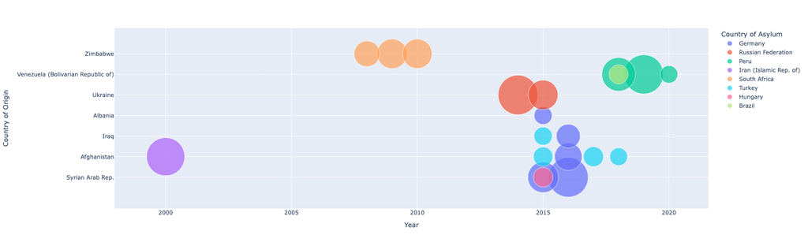

Top 20 Migration Corridors by Asylum Applicants

Second, these peak observations align closely with major global events and conflicts. For example, the surge of Afghan asylum seekers in 2000 reflects the instability caused by the Taliban regime. Similarly, the high number of Syrian applications to Germany during 2015-2016 correlates with the Syrian Civil War and the European migration crisis. More recently, the large-scale asylum applications from Venezuelans between 2018 and 2019 coincide with the country’s presidential crisis and resulting humanitarian disaster.

Overall, this visualization provides a nuanced view of asylum-seeking trends, emphasizing how specific geopolitical events and regional factors shape migration flows. It complements broader analyses by highlighting key origin-destination relationships and the dynamics of asylum-seeking behavior during periods of crisis.

## Visualization 3:

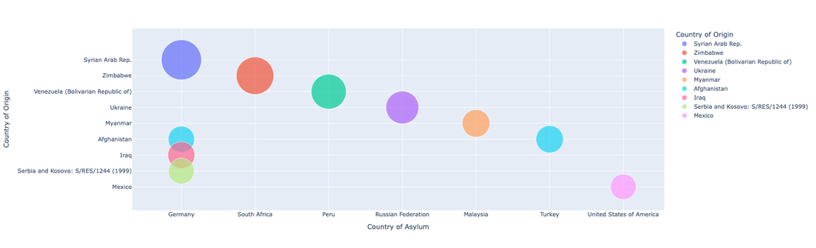

Top 10 Migration Corridors by Asylum Applicants

Smaller countries, such as Zimbabwe and Myanmar, also contribute to the global migration landscape with distinct migration links, illustrating the widespread nature of these movements. This visualization effectively captures the scale and directionality of major international migration corridors, offering insights into the historical, economic, and geopolitical factors influencing these flows.

# Conclusion

Through a series of visualizations, we have explored the global patterns of asylum applications over the past two decades, uncovering compelling trends and insights. The animated map provided a macro-level view, revealing the temporal and geographic hotspots of asylum-seeking activity, particularly in regions affected by conflict and instability, such as the Middle East and Central Africa. It also highlighted notable surges during global crises, such as the European migrant crisis and the mass displacement of the Rohingya.

Together, these visualizations illuminate the multifaceted nature of asylum-seeking trends, offering not just a snapshot of migration dynamics but also a window into the human stories behind the data. This analysis reinforces the importance of using data-driven approaches to inform humanitarian efforts, migration policy, and global resource allocation. While the visualizations provide a rich perspective, they also point to the need for deeper exploration into the underlying drivers of these trends, ensuring that global migration challenges are met with informed and compassionate responses.